# Opciones para completar datos faltantes

En el notebook 6 habíamos realizado una primera aproximación. Veamos ahora un poco más en profundidad acerca de cómo trabajar con datos faltantes. Para ello, vamos a cargar el dataset de trabajo y a guardarlo en una variable. Vamos a especificar que el dataset tiene cabecera y además, vamos a indicar que no identifique los strings como factores, ya que el dataset tiene valores NA que podrían interpretarse como valores discretos.

```r
housing.data <- read.csv ("/Users/Ariel/Library/Mobile Documents/com~apple~CloudDocs/AADD/DataScience-con-RStudio/Datos/tema1/housing-with-missing-value.csv", header = TRUE, stringsAsFactors = FALSE)
```

Ante este dataframe, más o menos grande, el primer acercamiento es hacer un *resumen* de toda la información contenida. Esto lo conseguimos con la función **summary**.

```r
summary(housing.data) -> summary_housing
View (summary_housing)
head (summary_housing, 6)
```

```
       X              crim                zn             indus            chas              nox               rm             age              dis              rad
 Min.   :  1.0   Min.   : 0.00632   Min.   :  0.00   Min.   : 0.46   Min.   :0.00000   Min.   :0.3850   Min.   :3.561   Min.   :  2.90   Min.   : 1.130   Min.   : 1.000
 1st Qu.:127.2   1st Qu.: 0.08204   1st Qu.:  0.00   1st Qu.: 5.19   1st Qu.:0.00000   1st Qu.:0.4490   1st Qu.:5.886   1st Qu.: 45.02   1st Qu.: 2.100   1st Qu.: 4.000
 Median :253.5   Median : 0.25651   Median :  0.00   Median : 9.69   Median :0.00000   Median :0.5380   Median :6.208   Median : 77.50   Median : 3.207   Median : 5.000
 Mean   :253.5   Mean   : 3.61352   Mean   : 11.36   Mean   :11.14   Mean   :0.06917   Mean   :0.5547   Mean   :6.285   Mean   : 68.57   Mean   : 3.795   Mean   : 9.515
 3rd Qu.:379.8   3rd Qu.: 3.67708   3rd Qu.: 12.50   3rd Qu.:18.10   3rd Qu.:0.00000   3rd Qu.:0.6240   3rd Qu.:6.623   3rd Qu.: 94.08   3rd Qu.: 5.188   3rd Qu.:24.000
 Max.   :506.0   Max.   :88.97620   Max.   :100.00   Max.   :27.74   Max.   :1.00000   Max.   :0.8710   Max.   :8.780   Max.   :100.00   Max.   :12.127   Max.   :24.000
      tax           ptratio            b              lstat            medv
 Min.   :187.0   Min.   :12.60   Min.   :  0.32   Min.   : 1.73   Min.   : 5.00
 1st Qu.:279.0   1st Qu.:17.40   1st Qu.:375.38   1st Qu.: 6.95   1st Qu.:17.02
 Median :330.0   Median :19.10   Median :391.44   Median :11.36   Median :21.20
 Mean   :408.2   Mean   :18.47   Mean   :356.67   Mean   :12.65   Mean   :22.53
 3rd Qu.:666.0   3rd Qu.:20.20   3rd Qu.:396.23   3rd Qu.:16.95   3rd Qu.:25.00
 Max.   :711.0   Max.   :22.00   Max.   :396.90   Max.   :37.97   Max.   :50.00
```

> Toda esta información se ve un poco mejor haciéndolo directamente en consola: además es posible que el número de NAs no se muestre en los visores sino exclusivamente en consola. Ejecutamos **summary(housing.data)** directamente en la pestaña **Console**.

La función **summary** hará un resumen por columnas de toda la información, entregándonos el mínimo, la media, la mediana, el máximo y, de haberlos, el número de observaciones $NA$. En este caso, observamos que en las variables *rad* y *ptratio* hay al menos 40 observaciones como $NA$. De nuevo, es posible que el número de $NAs$ no se muestre en visores sino solamente en consola.

### Opciones para completar estos datos.

#### A) Podríamos omitir todos los datos $NA$, con la función **na.omit**

```r
housing.data1 <- na.omit(housing.data)
```

Veremos que así todos los $NAs$ desaparecen **PERO SE HABRÁN RECALCULADO LOS VALORES YA QUE SE ELIMINAN OBSERVACIONES Y HABRÁN VARIADO**.

#### B) Podríamos omitir todos los datos $NA$ unicamente de ciertas columnas (mientras nos quedamos con valores $NAs$ de otras columnas)

```r
drop_na <- c("rad")
housing.data.2 <- housing.data [
  complete.cases(housing.data[, !(names(housing.data))%in% drop_na]),
  ]
```

En este ejemplo, guardamos el nombre de la columna “rad” (que contiene $NAs$ **QUE QUEREMOS MANTENER**), en una nueva variable que llamamos *drop_na*.

Luego, generamos un nuevo dataframe (llamado *housing.data.2*) donde guardaremos todas las columnas del dataframe anterior (por eso tenemos la sintaxis **housing.data[ blablabla **,** ]**).

Esa sintaxis *blablabla* es la que nos permitirá escoger las filas (ya que está antes de la coma en los corchetes). En ella usamos la función **complete.cases** (que devuelve un array de booleanos analizando si la fila esté completa).

¿Y qué va a analizar **complete.cases**? Pues accederá a todas las filas ([,)y a las columnas cuyo nombre NO ESTÉ GUARDADO EN LA VARIABLE *drop_na* (!(names(housing.data))%in% drop_na]).

#### C) Podríamos eliminar toda la columna, asígnando el valor NULL

> housing.data$rad -> NULL #Eliminamos toda la columna “rad”.

#### D) Podríamos eliminar ciertas columnas con $NA$ y quedarnos con aquellas que no contienen $NA$.

```r
drops <- c("rad", "ptratio")
housing.data.3 <- housing.data [, !(names(housing.data) %in% drops)]
```

En esta última sintaxis, nos quedamos con todas las filas del dataset *housing.data* pero nos quedamos únicamente con aquellas columnas cuyo nombre no se encuentre entre los contenidos en la variable *drops*. En este caso, eliminaríamos 2 columnas.

Hasta ahora hemos destruído todos los datos, pero ahora vamos a usar otro paquete para no ir tan “a saco”: se llama Hmisc ya que contiene varios paquetes interesantes (es posible que tengamos que instalarla)

```r
library (Hmisc)
```

De esta librería utilizaremos la función *impute* (RECORDEMOS QUE EL SIGNIFICADO INGLÉS SE REFIERE A “IMPUTAR” ALGO UNA VEZ REALIZADO ALGÚN CÁLCULO O TRANSFORMACIÓN), que nos permite reemplazar todos los valores $NA$ con otros valores, como el promedio, la mediana, constantes, etc. Normalmente, los $NAs$ se reemplazan con media o mediana.

```r
housing.data.copy1 <- housing.data #vamos a hacer una copia del dataframe y lo guardamos en una nueva variable
```

Usando la función *impute* del paquete *Hmisc*, podríamos rellenar cada valor de $NA$ de una columna con $NAs$ por el valor de la media de la columna. Para ello, accedemos a la columna *ptratio* (con la sintaxis del dólar) y aplicamos la función *impute* y le indicamos que lo reemplace con la media y vuelva a guardarlo en dicha columna.

```r
housing.data.copy1$ptratio <- impute(housing.data.copy1$ptratio, mean)
```

Aplicamos lo mismo para la otra columna que tiene $NAs$:

```r
housing.data.copy1$rad <- impute(housing.data.copy1$rad, mean) #En lugar de mean podríamos usar un número constante o lo que sea.
```

Como vemos, en *impute* podemos indicar la columna a modificar y la función a aplicar (mean, median, etc., e incluso un valor constante).

Pero incluso antes de comenzar a modificar o borrar datos faltantes, podríamos intentar buscar o comprender los patrones (si existen) de los valores faltantes. Esto lo realizaremos con la función *md.pattern* del paquete *mice* (es posible que tengamos que instalarlo).

```
    X crim zn indus chas nox rm age dis tax b lstat medv rad ptratio
431 1    1  1     1    1   1  1   1   1   1 1     1    1   1       1  0
35  1    1  1     1    1   1  1   1   1   1 1     1    1   1       0  1
35  1    1  1     1    1   1  1   1   1   1 1     1    1   0       1  1
5   1    1  1     1    1   1  1   1   1   1 1     1    1   0       0  2
    0    0  0     0    0   0  0   0   0   0 0     0    0  40      40 80
```

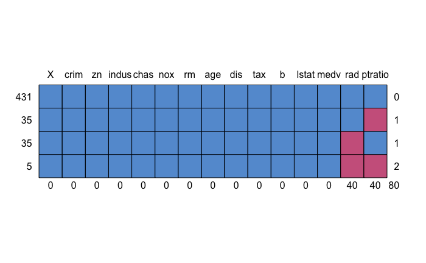

```r
library(mice)
md.pattern(housing.data)
```

Aunque el paquete devuelve una imagen, vamos a usar la librería *VIM* (en mayúsculas). Usaremos la función *aggr*, y con la función *col* podemos modificar los colores (siempre el primer color es para datos conocidos, en tanto que el segundo es para datos desconocidos). También usaremos el parámetro *numbers* para ver el porcentaje de casos. El parámetro *sortVars* nos organizará las variables de mayor a menor y, en el caso de necesitar modificar las etiquetas, podemos usar el parámetro *labels*. En el caso de necesitar disminuir el tamaño de las fuentes podemos usar el parámetro *cex.axis*. Dado que tenemos dos gráficos, podemos usar el parámetro *gap* para ir cerrando el “hueco” que los distancia. Finalmente, podemos modificar las etiquetas de los ejes: en este caso tenemos dos ejes Y por lo que tenemos que ingresarlo como un vector.

```
 Variables sorted by number of missings:
```

| Variable | Count |
| --- | --- |
| rad | 0.07905138 |
| ptratio | 0.07905138 |
| X | 0.00000000 |
| crim | 0.00000000 |
| zn | 0.00000000 |
| indus | 0.00000000 |
| chas | 0.00000000 |
| nox | 0.00000000 |
| rm | 0.00000000 |
| age | 0.00000000 |

[output cut: 5 more lines]

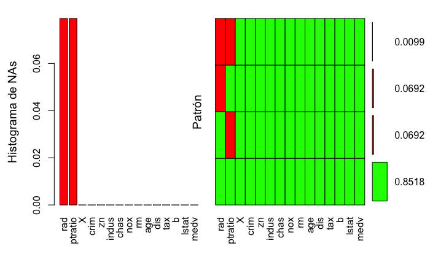

```r
library(VIM)
aggr(housing.data,
     col=c('green', 'red'),
     numbers = TRUE,
     sortVars = TRUE,
     labels = names (housing.data),
     cex.axis = 1,
     gap = 1,
     ylab = c("Histograma de NAs", "Patrón"))
```

> Los valores a la izquierda representan la proporción, en lugar del número total como en el gráfico anterior. En este caso, el 85,18% de los datos están completos, en tanto que el 6,92% tienen valores de NA en una variable y y el 0,99% tienen valores NAs en dos variables.